# Assignment 4 Specialty Toys

Torreon Green

11/11/2019

#1. Normal Probability Distribution to approximate the Demand Distribution for Specialty Toys

#The expected demand, 20,000 units, is also the mean of the demand. If there is a .95 probability that demand would be between 10,000 and 30,000 units, then each of these amounts are 2 standard deviations away from the mean. Therefore, the standard deviation is 5,000 units. The probability distribution to represent these amounts is shown below.

```r
x.values <-seq(0,40000,1)
sd.values <-seq(0,40000,5000)
zeros9 <-rep(0,9)
```

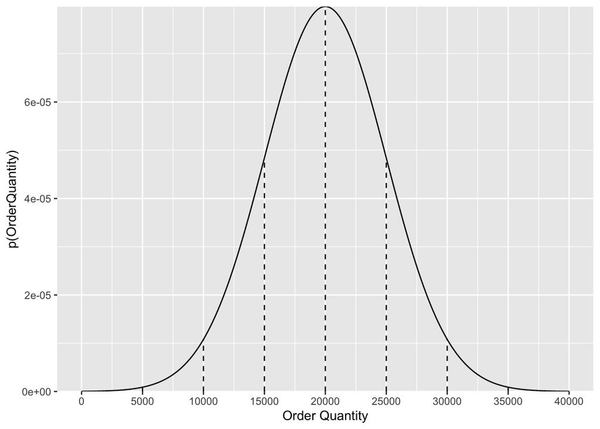

```r
library(ggplot2)

ggplot(data=NULL, aes(x=x.values,y=dnorm(x.values,m=20000,s=5000))) + geom_line() + labs(x="Order Quantity",
y="p(OrderQuantity)") + scale_x_continuous(breaks=sd.values,labels = sd.values) + geom_segment((aes(x=sd.values,y=zeros9,xend=sd.values,yend=dnorm(sd.values,m=20000,s=5000))),
linetype = "dashed") +scale_y_continuous(expand = c(0,0))
```

#2. The probability of a stock-out is shown below for the following order quantities: a. For 15,000 units the probability is .84. b. For 18,000 units, the probability is .66. c. For 24,000 units, the probability is .21. d. For 28,000 units, the probability is .05.

```r
# a
pnorm(15000, mean = 20000, sd = 5000, lower.tail=FALSE)
```

```
## [1] 0.8413447
```

```r
# b
pnorm(18000, mean = 20000, sd = 5000, lower.tail=FALSE)
```

```
## [1] 0.6554217
```

```r
# c
pnorm(24000, mean = 20000, sd = 5000, lower.tail=FALSE)
```

```
## [1] 0.2118554
```

```r
# d
pnorm(28000, mean = 20000, sd = 5000, lower.tail=FALSE)
```

```
## [1] 0.05479929
```

#3. The projected profit under the three following scenarios is shown below. Worst case:sales = 10,000 units, Most likely: sales =20,000 units, Best case: sales=30,000 units. The selling price is $24 per unit and the per unit cost is $16. Surplus inventory is sold at $5 per unit.

```r
order.quant <-c(15000, 18000, 24000, 28000)
worst <-(10000)
most.likely <-(20000)
best <-(30000)

# worst case
worst*24-order.quant*16 +(order.quant - worst)*5
```

```
## [1]   25000   -8000  -74000 -118000
```

```r
# most likely case
ifelse(order.quant<20000, order.quant*24 - order.quant*16, most.likely*24 - order.quant*16 + (order.quant - most.likely)*5)
```

```
## [1] 120000 144000 116000  72000
```

```r
# best case
ifelse(order.quant<30000, order.quant*24 - order.quant*16, best*24 - order.quant*16 + (order.quant - best)*5)
```

```
## [1] 120000 144000 192000 224000
```

#4a The quantity that should be ordered to have only a 30% chance of any stock-out is 22,650 units. A 30% chance of a stock-out corresponds to a z-score of .53 (probability of 1-.7019 = .2981). This score is multiplied times the standard deviation and the expected demand is added to it.

```r
stock.outqty <-(.53)*(5000)+20000
print(stock.outqty)
```

```
## [1] 22650
```

#4b The projected profit under worst case, the most likely case, and the best case scenarios is shown below.

#The order quantity is 22,650 units and under the worst and most likely case scenarios, there will be surplus inventory of 12,650 and 2,650 units respectively. These units will be sold at a reduced price of $5 per unit.

#The best case scenario will result in lost sales because the store will not be able to provide the amount of inventory to reach the 30,000 units.

```r
# worst case scenario
worst*24-stock.outqty*16 + (stock.outqty-worst)*5
```

```
## [1] -59150
```

```r
# most likely case
most.likely*24-stock.outqty*16 + (stock.outqty-most.likely)*5
```

```
## [1] 130850
```

```r
# best case
22650*24-stock.outqty*16
```

```
## [1] 181200
```

#Also, ordering 28,000 units will produce a profit of $224,000 and $48,000 in lost sales. However, ordering this amount will only generate revenue of $72,000 (of which 8000*5 = $40,000 can be attributed to sales of surplus inventory) under the most likely scenario with a .05 probability of a stock-out. Ordering this amount presents a wide range for potential profits under both of these methods:$224000 -72,000 = $152,000.

#Under the most-likely scenario, ordering a quantity of 18,000 units generates a revenue of $144,000 with $48,000 in lost sales and a .66 probability of a stock-out. Because of the high probability of a stock-out, I would not suggest ordering this amount.